# Data Visualization in R

# Summarized data and `stat`s

Sometimes data comes already summarized. As an example, you can have the following frequency tables without the original data.

```r
ChickWeightFreq <- ChickWeight %>% group_by(Diet) %>% summarize(n=n())
ChickWeightFreq
```

```
## Source: local data frame [4 x 2]
##
##     Diet     n
##   (fctr) (int)
## 1      1   220
## 2      2   120
## 3      3   120
## 4      4   118
```

You can try to build the previous plot in the same way.

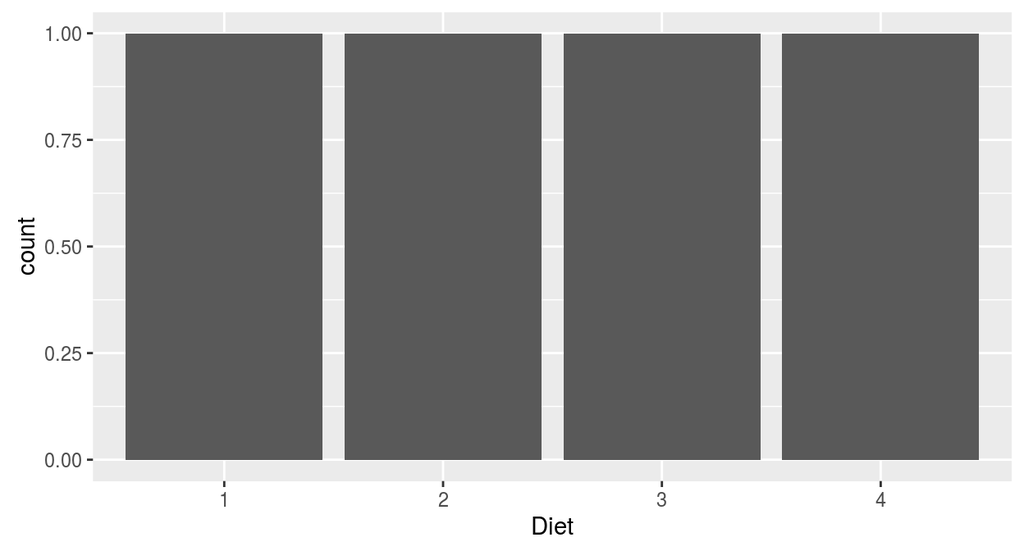

```r
ggplot(data=ChickWeightFreq, mapping=aes(x=Diet)) + geom_bar()
```

The result is a plot with four bars of length 1. Why? The reason is quite simple. By default, `geom_bar()` scans the `Diet` column counting how many observations have Diet=1, how many have Diet=2 and so on. In this case, you must tell `ggplot` you already have the count.

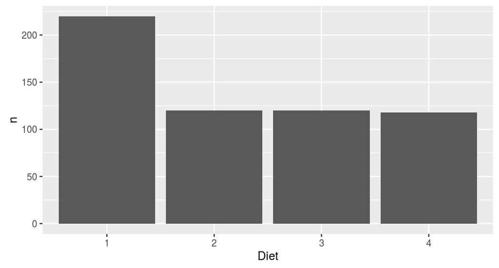

```r
ggplot(data=ChickWeightFreq, mapping=aes(x=Diet, y=n)) + geom_bar(stat="identity")
```

Since you have an `y` variable containing frequencies, you tell `ggplot` the variable containing counts (`y=n` in the example) and to `geom_bar` that `stat="identity"` must be used.

A statistical transformation, or `stat`, transforms the data, typically by summarizing it in some manner. By default, almost all `geom`s seen until now uses `stat="identity"`, that do not transform data. As just seen, by default `geom_bar()` uses `stat="count"` that counts the number of cases at each `x` position. If you do not want to transform your data, `stat="identity"` must be supplied.

# Stacked and grouped bar plots

If you are a quality engineer analysing the `bands` data, you may be interested to the number of presses for each type, distinguishing them by the cylinder size.

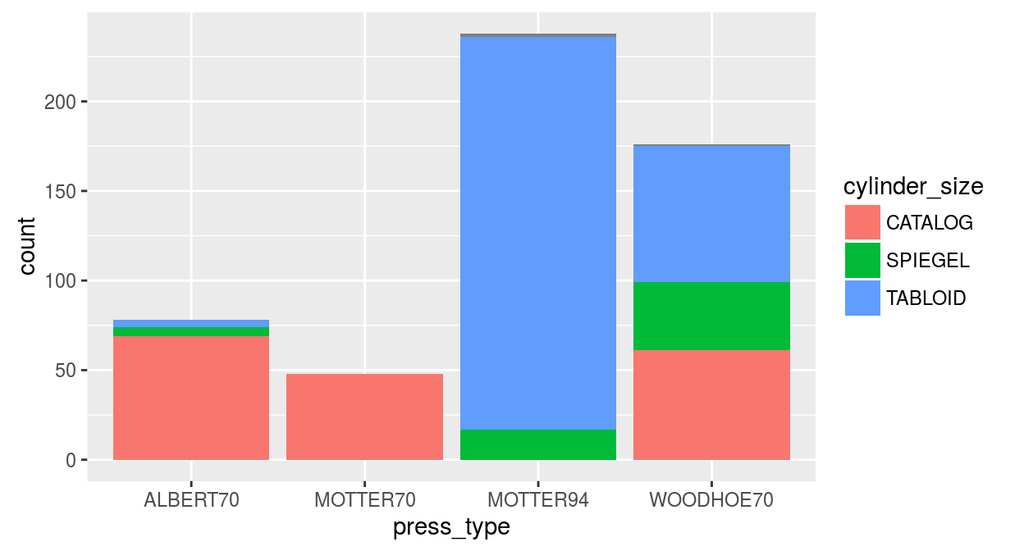

```r
ggplot(data=bands, mapping=aes(x=press_type, fill=cylinder_size)) + geom_bar()
```

Mapping `fill` to `cylinder_size` does the job. Notice a small gray area at the top of the last two bars: this means there are few cases in which `cylinder_size` is missing.

Sometimes you may be interested at the distribution of `cylinder_size` for each `press_type`.

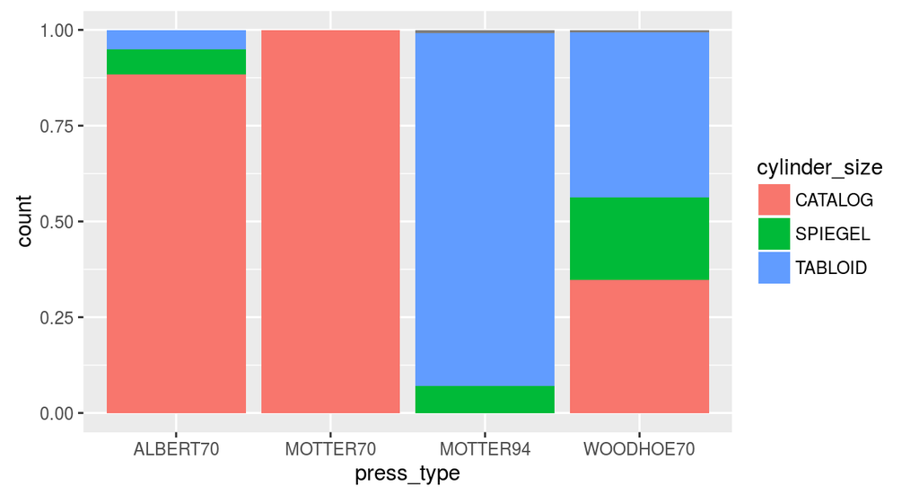

```r
ggplot(data=bands, mapping=aes(x=press_type, fill=cylinder_size)) + geom_bar(position="fill")
```

In the case you prefer a bar for each combination of `press_type` and `cylinder_size`, you can `dodge` the bars.

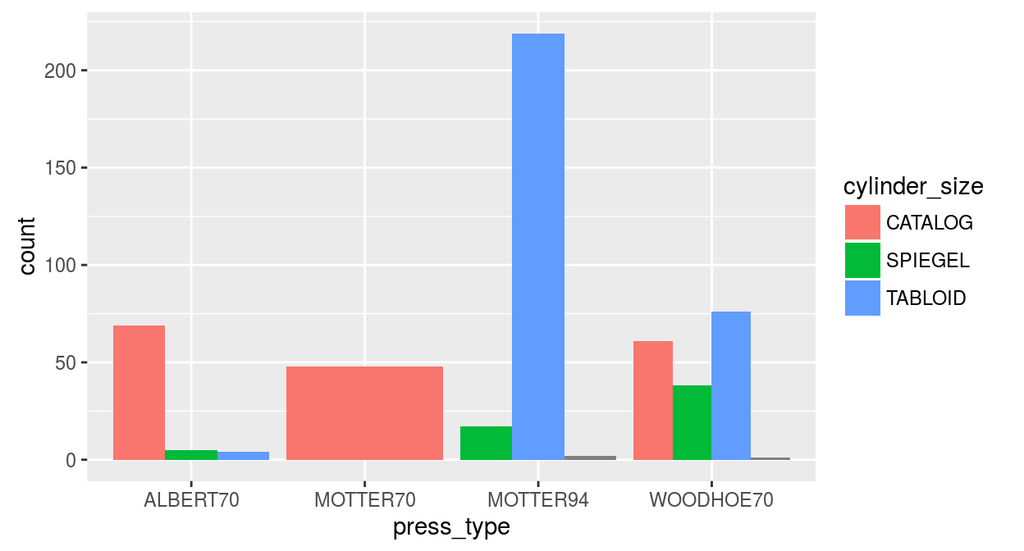

```r
ggplot(data=bands, mapping=aes(x=press_type, fill=cylinder_size)) + geom_bar(position="dodge")
```

Notice that `position="dodge"` is a short key for `position=position_dodge()` with its default value and you can modify this value to add space between bars. In the case you want to add space between bars, you probably want also to modify the `width` in order to add spaces among each group of bars.

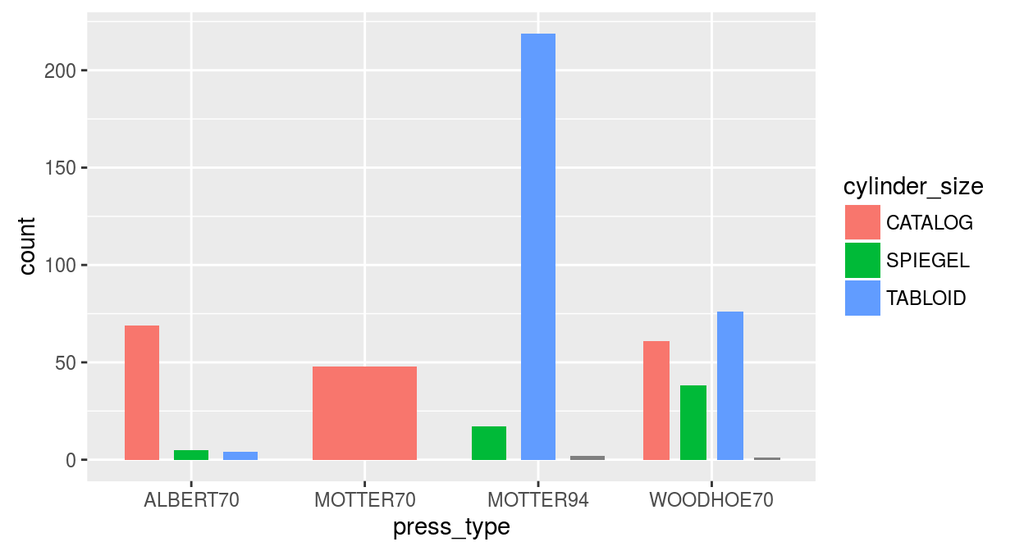

```r
ggplot(data=bands, mapping=aes(x=press_type, fill=cylinder_size)) +
  geom_bar(position=position_dodge(0.85), width=0.6)
```

The `width` in `geom_bar()` determines the width of the bar; the `width` in `position_dodge()` determines the position of each bar. Probably you can easily understand their behaviour after you play with them for a while.

All data related to `MOTTER70` press has `CATALOG` as `cylinder_size`. In this case, the bars related to other `cylinder_size` are missing and the `MOTTER70` bar will expand to fill the whole space.

To avoid this behaviour you must have at least a `NA` value for each combination of factors. Since both `ggplot2` when you plot and `dplyr` when you build a frequency table, do not show the count for missing combinations, you should manually build a frequency table like the following one.

```r
bands_freq_na <- bands %>% group_by(press_type, cylinder_size) %>% summarise(n = n()) %>%
  right_join(
    expand.grid(
      press_type = bands %>% magrittr::use_series(press_type) %>% levels,
      cylinder_size = c(bands %>% magrittr::use_series(cylinder_size) %>% levels, NA)
    )
  )
bands_freq_na
```

```
## Source: local data frame [16 x 3]
## Groups: press_type [?]
##
##    press_type cylinder_size     n
##        (fctr)        (fctr) (int)
## 1    ALBERT70       CATALOG    69
## 2    MOTTER70       CATALOG    48
## 3    MOTTER94       CATALOG    NA
## 4   WOODHOE70       CATALOG    61
## 5    ALBERT70       SPIEGEL     5
## 6    MOTTER70       SPIEGEL    NA
## 7    MOTTER94       SPIEGEL    17
## 8   WOODHOE70       SPIEGEL    38
## 9    ALBERT70       TABLOID     4
## 10   MOTTER70       TABLOID    NA
## 11   MOTTER94       TABLOID   219
## 12  WOODHOE70       TABLOID    76
## 13   ALBERT70            NA    NA
## 14   MOTTER70            NA    NA
## 15   MOTTER94            NA     2
## 16  WOODHOE70            NA     1
```

At this point, you can easily build the plot starting from frequency table. Just remember to map the counts to `y` and to add `stat="identity"` to `geom_bar()`.

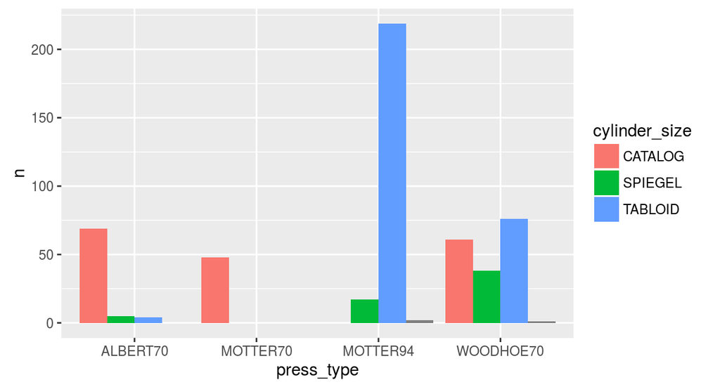

```r
ggplot(data=bands_freq_na, mapping=aes(x=press_type, y=n, fill=cylinder_size)) +
  geom_bar(stat="identity", position="dodge")
```

As we see in the previous plots, `cylinder_size` is a factor variable with three levels: `CATALOG`, `SPIEGEL` and `TABLOID` but it has also missing values (`NA`).  
To visualize also missing values (`NA`) as `cylinder_size` level in plots legend, we have to recode its levels, adding also `NA` as level.

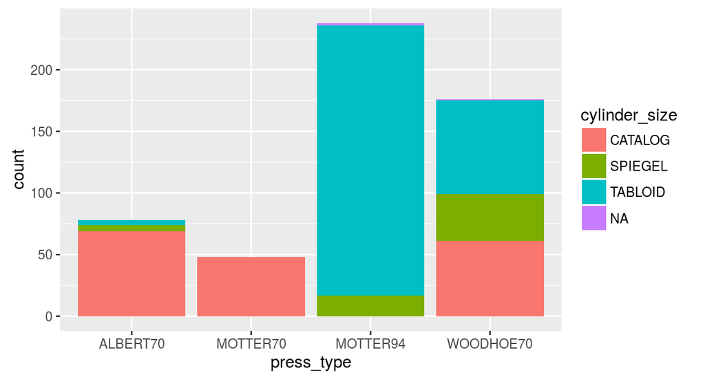

```r
bands <- bands %>% mutate(cylinder_size = as.character(cylinder_size), cylinder_size =ifelse(is.na(cylinder_size),"NA",cylinder_size),
  cylinder_size = factor(cylinder_size, levels= c("CATALOG", "SPIEGEL", "TABLOID", "NA"), labels = c("CATALOG", "SPIEGEL", "TABLOID", "NA")))

ggplot(data=bands, mapping=aes(x=press_type, fill=cylinder_size)) +
  geom_bar()
```

# Adding text to plots

Plots are useful to catch the eye of your audience but sometimes they cannot replace numbers or text. Adding text to a plot can help you to integrate information in your plot.

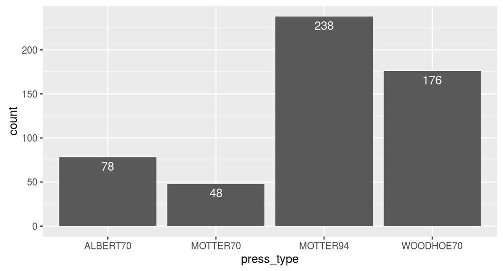

```r
bands_freq <- bands %>% group_by(press_type) %>% summarize(n=n())

ggplot(data=bands, mapping=aes(x=press_type)) +
  geom_bar() +
  geom_text(data=bands_freq, mapping=aes(y=n, label=n), vjust=1.5, colour="white")
```

`geom_text()` works as any other `geom` seen until now. It requires `x` and `y` coordinates; in this case, `x` is `press_type` and it is inherited from `ggplot()`, while `y` should be passed. Since `bands` data do not contains the count, that is computed by `stat_count` inside `geom_bar()`, default data are overwritten in `geom_text()` in order to use frequencies. `geom_text()` requires `label` that is the text to be written. Outside `aes()`, `vjust` move down (or up) the text and `colour` set text colour.